#### Statistics for Laboratory Scientists ( 140.615 )

## Non-linear Regression

#### Example from class: Michaelis-Menten equations

The data.

```r
library(SPH.140.615)
puro
```

```
##    conc vel     state
## 1  0.02  76   treated
## 2  0.02  47   treated
## 3  0.06  97   treated
## 4  0.06 107   treated
## 5  0.11 123   treated
## 6  0.11 139   treated
## 7  0.22 159   treated
## 8  0.22 152   treated
## 9  0.56 191   treated
## 10 0.56 201   treated
## 11 1.10 207   treated
## 12 1.10 200   treated
## 13 0.02  67 untreated
## 14 0.02  51 untreated
## 15 0.06  84 untreated
## 16 0.06  86 untreated
## 17 0.11  98 untreated
## 18 0.11 115 untreated
## 19 0.22 131 untreated
## 20 0.22 124 untreated
## 21 0.56 144 untreated
## 22 0.56 158 untreated
## 23 1.10 160 untreated
```

Plot the data, just for the untreated cells.

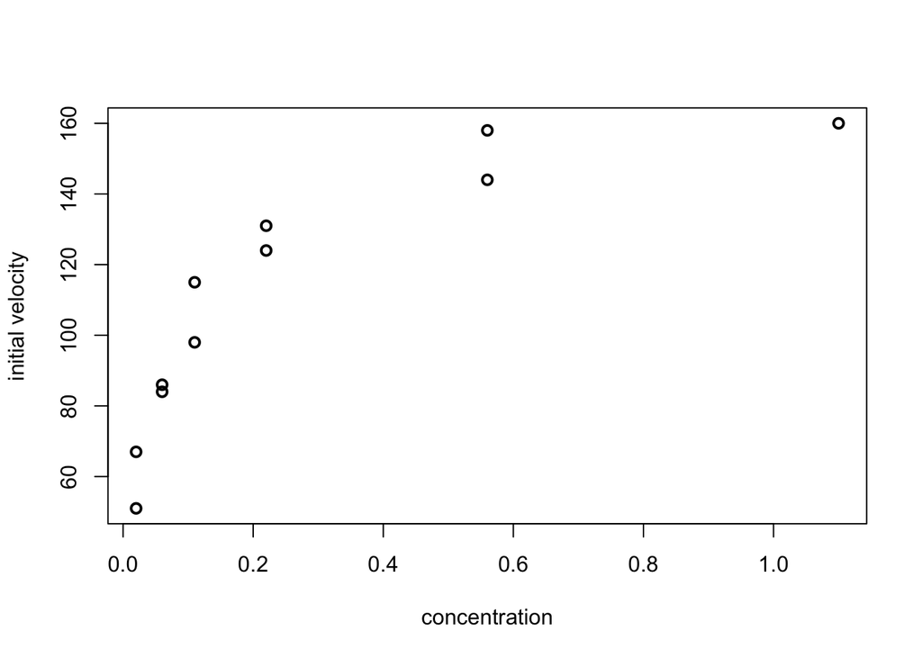

```r
plot(vel ~ conc, data=puro, subset=(state=="untreated"), xlab="concentration", ylab="initial velocity", lwd=2)
```

The regression of 1/V on 1/C, just with the data on untreated cells.

```r
temp <- lm(1/vel ~ I(1/conc), data=puro, subset=(state=="untreated"))
summary(temp)$coef
```

```
##                 Estimate   Std. Error   t value     Pr(>|t|)
## (Intercept) 0.0069721337 5.678297e-04 12.278565 6.331192e-07
## I(1/conc)   0.0002150012 2.479421e-05  8.671428 1.156213e-05
```

```r
vmax <- 1/temp$coef[1]
vmax
```

```
## (Intercept)
##    143.4281
```

```r
km <- temp$coef[2]*vmax
km
```

```
##  I(1/conc)
## 0.03083721
```

Plot the data with the regression line.

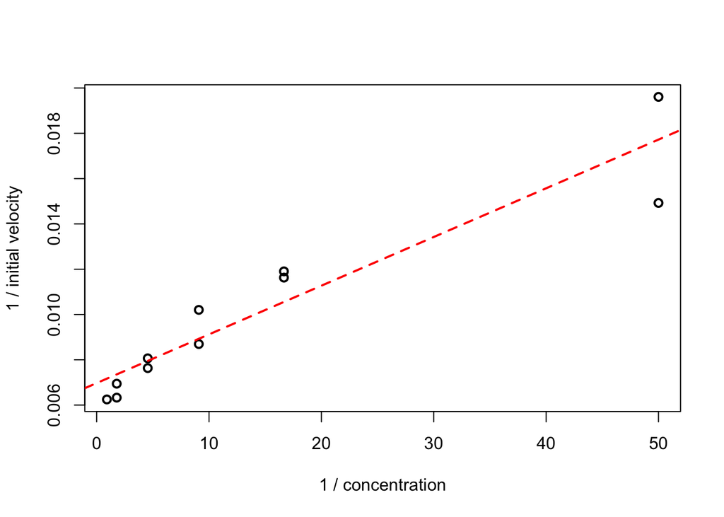

```r
plot(I(1/vel) ~ I(1/conc), data=puro, subset=(state=="untreated"),
     xlab="1 / concentration", ylab="1 / initial velocity", lwd=2)
abline(temp$coef, col="red", lty=2, lwd=2)
```

The non-linear fit.

```r
nls.out <- nls(vel ~ (Vm*conc)/(K+conc), data=puro, subset=(state=="untreated"), start = c(Vm=143,K=0.031))
summary(nls.out)$param
```

```
##        Estimate  Std. Error   t value     Pr(>|t|)
## Vm 160.28001125 6.480243120 24.733642 1.384612e-09
## K    0.04770813 0.007781868  6.130678 1.727056e-04
```

Plot the data, with both fitted curves.

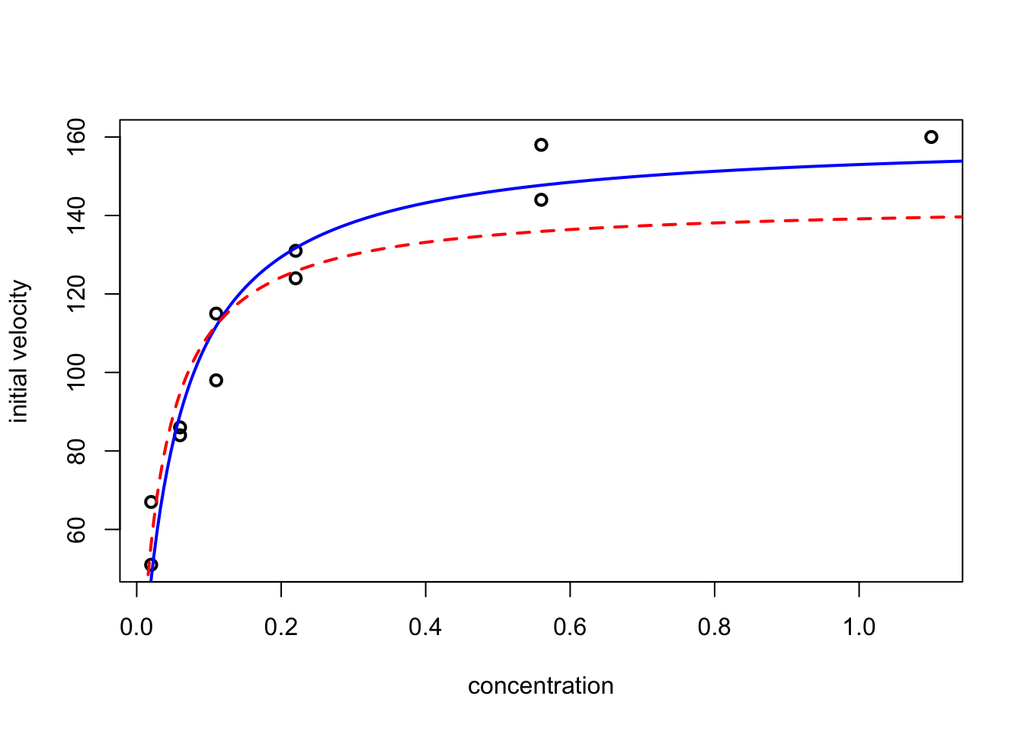

```r
plot(vel ~ conc, data=puro, subset=(state=="untreated"), xlab="concentration", ylab="initial velocity", lwd=2)
u <- par("usr")
x <- seq(u[1],u[2],length=250)
y1 <- 1/predict(temp, data.frame(conc=x))
y2 <- predict(nls.out, data.frame(conc=x))
lines(x,y2, lwd=2, col="blue")
lines(x,y1, lwd=2, col="red", lty=2)
```

Non-linear regression estimation for just the treated cells.

```r
nls.outB <- nls(vel ~ (Vm*conc)/(K+conc), data=puro, subset=(puro$state=="treated"), start=c(Vm=160,K=0.048))
summary(nls.outB)$param
```

```
##        Estimate  Std. Error   t value     Pr(>|t|)
## Vm 212.68377342 6.947156655 30.614507 3.241166e-11
## K    0.06412133 0.008280954  7.743229 1.565132e-05
```

Fit both regressions all in one.

```r
puro$x <- ifelse(puro$state=="treated",1,0)
nls.outC <- nls(vel ~ ((Vm+dV*x)*conc)/(K+dK*x+conc), data=puro, start=c(Vm=160,K=0.048,dV=0,dK=0))
summary(nls.outC)$param
```

```
##        Estimate  Std. Error   t value     Pr(>|t|)
## Vm 160.28012878 6.896020420 23.242409 2.040955e-15
## K    0.04770831 0.008281174  5.761057 1.496420e-05
## dV  52.40364441 9.551022356  5.486705 2.712600e-05
## dK   0.01641302 0.011428988  1.436087 1.672387e-01
```

Fit with the K’s constrained to be equal.

```r
nls.outD <- nls(vel ~ ((Vm+dV*x)*conc)/(K+conc), data=puro, start=c(Vm=160,K=0.048,dV=0))
summary(nls.outD)$param
```

```
##        Estimate  Std. Error   t value     Pr(>|t|)
## Vm 166.60407675 5.807428478 28.688098 1.006288e-17
## K    0.05797179 0.005910173  9.808816 4.372679e-09
## dV  42.02596380 6.272141186  6.700417 1.605939e-06
```

Plot data and both fits.

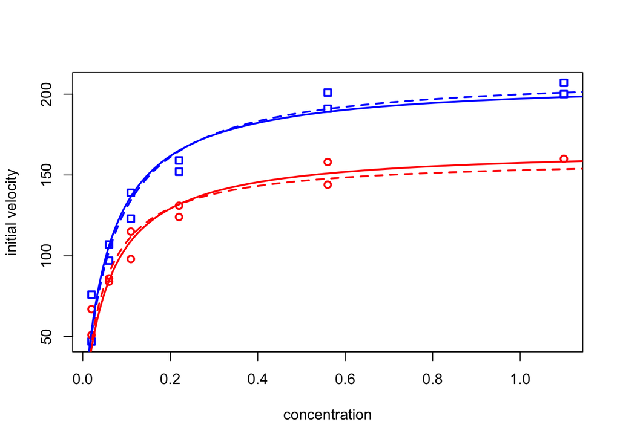

```r
plot(vel ~ conc, data=puro, xlab="concentration", ylab="initial velocity", lwd=2,
     pch=as.numeric(puro$state)-1, col=ifelse(puro$state=="treated","blue","red"))
u <- par("usr")
x <- seq(u[1],u[2],len=250)
y1 <- predict(nls.out, data.frame(conc=x))
y2 <- predict(nls.outB, data.frame(conc=x))
y3 <- predict(nls.outD, data.frame(conc=x, x=rep(0,length(x))))
y4 <- predict(nls.outD, data.frame(conc=x, x=rep(1,length(x))))
lines(x, y1, lwd=2, col="red", lty=2)
lines(x, y2, lwd=2, col="blue", lty=2)
lines(x, y3, lwd=2, col="red")
lines(x, y4, lwd=2, col="blue")
```

#### Example from class: the mud snails

The data.

```r
sediment
```

```
##    time pellets
## 1     6     119
## 2     6     111
## 3     6      87
## 4    12     348
## 5    12     210
## 6    12     272
## 7    18     438
## 8    18     778
## 9    18     548
## 10   24     774
## 11   24     896
## 12   24     670
## 13   42     896
## 14   42     729
## 15   42     886
## 16   78     763
## 17   78     954
## 18   78     954
```

Fit a cubic model. We need to use I() to get the square and cubic terms to work.

```r
lm.out <- lm(pellets ~ time + I(time^2) + I(time^3), data=sediment)
summary(lm.out)
```

```
##
## Call:
## lm(formula = pellets ~ time + I(time^2) + I(time^3), data = sediment)
##
## Residuals:
##     Min      1Q  Median      3Q     Max
## -154.63  -83.57   28.61   54.98  196.21
##
## Coefficients:
##               Estimate Std. Error t value Pr(>|t|)
## (Intercept) -3.389e+02  1.274e+02  -2.660 0.018668 *
## time         7.573e+01  1.543e+01   4.907 0.000231 ***
## I(time^2)   -1.545e+00  4.804e-01  -3.215 0.006228 **
## I(time^3)    9.942e-03  3.945e-03   2.520 0.024479 *
## ---
## Signif. codes:  0 '***' 0.001 '**' 0.01 '*' 0.05 '.' 0.1 ' ' 1
##
## Residual standard error: 112.2 on 14 degrees of freedom
## Multiple R-squared:  0.8961, Adjusted R-squared:  0.8738
## F-statistic: 40.23 on 3 and 14 DF,  p-value: 3.925e-07
```

Fit a “linear spline” model.

```r
f <- function(x,b0,b1,x0) ifelse(x<x0, b0+b1*x, b0+b1*x0)
nls.out <- nls(pellets ~ f(time,b0,b1,x0), data=sediment, start=c(b0=0,b1=50,x0=30))
summary(nls.out)$param
```

```
##      Estimate Std. Error   t value     Pr(>|t|)
## b0 -146.00000  71.292691 -2.047896 5.849712e-02
## b1   38.90556   4.338735  8.967027 2.055707e-07
## x0   25.95173   1.780619 14.574561 2.911998e-10
```

Plot the data and the fitted curves.

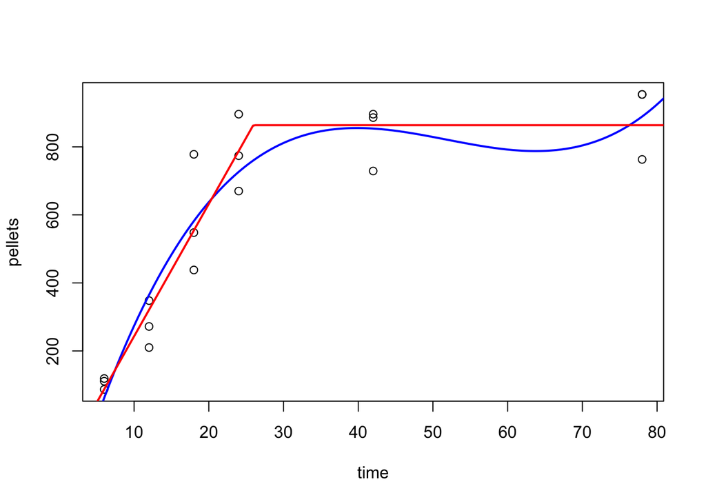

```r
plot(pellets ~ time, data=sediment)
u <- par("usr")
x <- seq(u[1],u[2],length=250)
y <- predict(lm.out, data.frame(time=x))
lines(x, y, col="blue", lwd=2)
y2 <- predict(nls.out, data.frame(time=x))
lines(x,y2,col="red",lwd=2)
```

#### Example from class: Michaelis-Menten equations (revisited)

A closer look at the residual sum of squares and the inference for the parameters Vmax and K.

We are using the data from the untreated cells first.

```r
nls.out <- nls(vel ~ (Vm*conc)/(K+conc), data=puro, subset=(state=="untreated"), start = c(Vm=143,K=0.031))
summary(nls.out)$param
```

```
##        Estimate  Std. Error   t value     Pr(>|t|)
## Vm 160.28001125 6.480243120 24.733642 1.384612e-09
## K    0.04770813 0.007781868  6.130678 1.727056e-04
```

Visualize the residual sum of squares in a neighborhood of the parameter estimates, show the location of the least squares estimates, and show the confidence intervals from the `confint` function. We are truncating the RSS in the image (red colors).

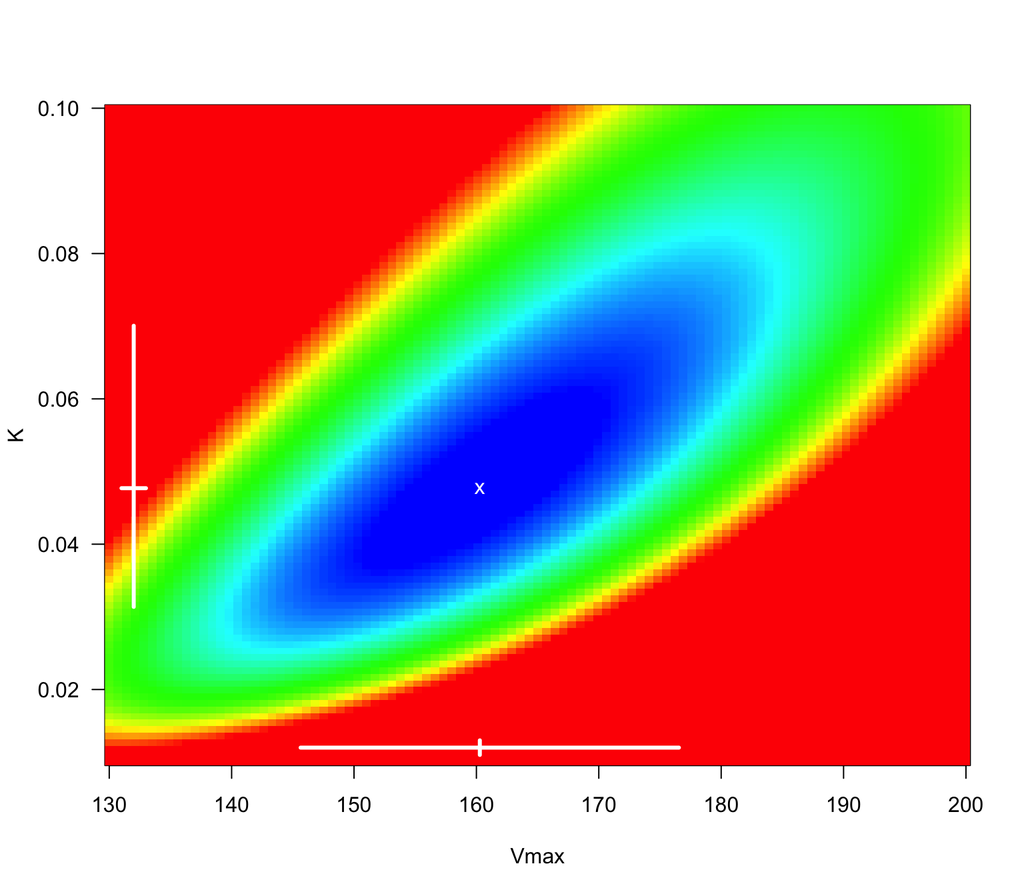

```r
dat <- subset(puro,state=="untreated")
f <- function(z,dat) sum((dat$vel-(z[2]*dat$conc)/(z[1]+dat$conc))^2)
hm <- 101
K <- seq(0.01,0.1,length=hm)
V <- seq(130,200,length=hm)
z <- expand.grid(K,V)
rss <- apply(z,1,f,dat=dat)
cut <- 5000
rss[rss>cut] <- cut
fit <- summary(nls.out)$param[,1]
cis <- suppressMessages(confint(nls.out))
par(las=1)
image(V,K,matrix(rss,ncol=hm,byrow=T),xlab="Vmax",col=rev(rainbow(256,start=0,end=2/3)))
text(fit[1],fit[2],"x",col="white")
lines(cis[1,],rep(0.012,2),col="white",lwd=3)
lines(rep(fit[1],2),c(0.011,0.013),col="white",lwd=3)
lines(rep(132,2),cis[2,],col="white",lwd=3)
lines(c(131,133),rep(fit[2],2),col="white",lwd=3)
```

Notice that the confidence intervals are not symmetric! The `confint` function uses a more complicated method (profiling) to generate these intervals. The methods are described in ore detail in the book *Modern Applied Statistics with S* by Venables and Ripley.

https://www.stats.ox.ac.uk/pub/MASS4/

```r
confint(nls.out)
```

```
##           2.5%        97.5%
## Vm 145.6369544 176.54440158
## K    0.0313746   0.07006131
```

Below are the symmetric confidence intervals based on a normality assumption of the parameter estimates. Note that the p-values in the summary are derived making that normality assumption!

```r
fit <- summary(nls.out)$param
fit[1,1]+c(-1,1)*qt(0.975,9)*fit[1,2]
```

```
## [1] 145.6207 174.9393
```

```r
fit[2,1]+c(-1,1)*qt(0.975,9)*fit[2,2]
```

```
## [1] 0.03010432 0.06531194
```

Revisiting our model using both the treated and untreated cells.

```r
nls.outC <- nls(vel ~ ((Vm+dV*x)*conc)/(K+dK*x+conc), data=puro, start=c(Vm=160,K=0.048,dV=0,dK=0))
summary(nls.outC)$param
```

```
##        Estimate  Std. Error   t value     Pr(>|t|)
## Vm 160.28012878 6.896020420 23.242409 2.040955e-15
## K    0.04770831 0.008281174  5.761057 1.496420e-05
## dV  52.40364441 9.551022356  5.486705 2.712600e-05
## dK   0.01641302 0.011428988  1.436087 1.672387e-01
```

```r
confint(nls.outC)
```

```
##            2.5%        97.5%
## Vm 145.85284480 176.28020955
## K    0.03158687   0.06965928
## dV  31.33677121  73.09295345
## dK  -0.01042896   0.04186662
```

The confidence interval for dK contains zero, so it is plausible that the rate constant K is the same for the treated and untreated cells.